# Research Methods in Political Science I

Likelihood Function

Yuki Yanai

December 9, 2015

## Preparation

Import packages.

```r
library("ggplot2")
library("reshape2")
```

## Likelihood Functions

### Example 1: Binomial Model of Coin Flips

Suppose we have a coin landing heads-up with the probabilty $\theta$. We flipped it 10 times and got 8 heads and 2 tails. We’d like to have a function to find the value of $\hat{\theta}$ that is most likely to give us the data $D=${8 heads out of 10 flips}. That is, we wanna create a likelihood function of $\theta$ given $D$. The likelihoodn funcion can be writte as
$$L(\theta | D) = \mathrm{Pr}(D | \theta).$$
The right-hand of the equation is the PMF of the binomial distribution with $n = 10$ trials and the prbablity of success $\theta$. Thus,
$$L(\theta |D) = \binom{10}{8} \theta^8 (1-\theta)^{10-2} = 45\theta^8 (1-\theta)^2.$$
This is a function showing how likely each value of $\theta$ is as probability that generates the data $D$.

Let’s define this funciton in R.

```r
lik_1 <- function(theta) {
    ## Argument: the probability of getting head by a coin flip
    ## Return: likelihood of theta given that we got 8 heads out of 10 flips
    L <- 45 * theta^8 * (1 - theta)^2
    return(L)
}
```

This funciton allows us to calculate the likelihood of a spccific value of $\theta$ given the observe data. For instance, the likelihoods for $\theta=0, 0.2, 0.7, 1$ are

```r
lik_1(0); lik_1(.2); lik_1(.7); lik_1(1)
```

```
## [1] 0
## [1] 7.3728e-05
## [1] 0.2334744
## [1] 0
```

To understand the likelihood function better, let’s draw a graph of the function. Because $\theta$ is probability, $\theta \in [0,1]$.

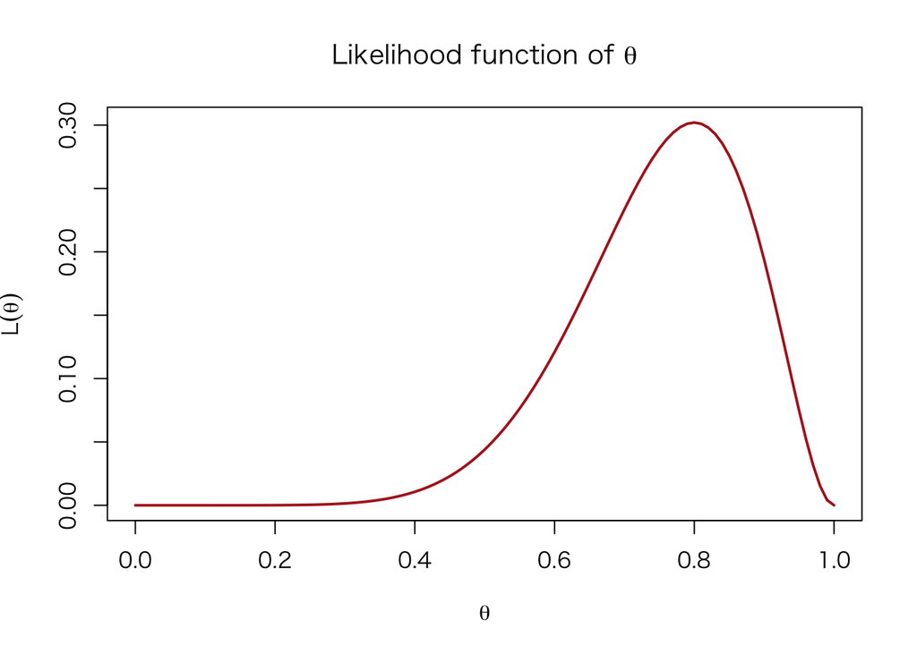

```r
curve(lik_1, from = 0, to = 1, lwd = 2, col = "firebrick",
      xlab = expression(theta), ylab = expression(L(theta)),
      main = expression(paste("Likelihood function of ", theta)))
```

If you’d like a little prettier one by ggplot2:

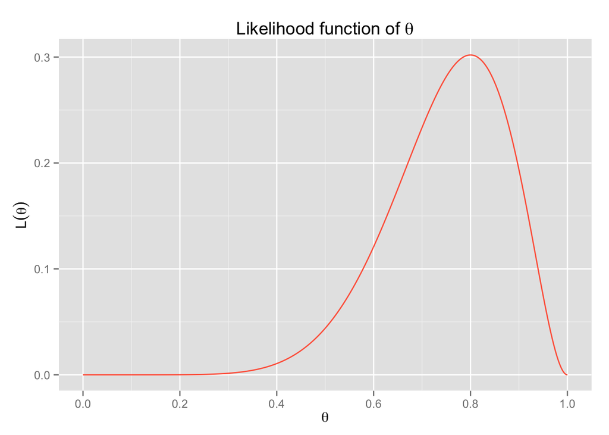

```r
v_theta <- seq(0, 1, length = 1000)
lik_theta <- lik_1(v_theta)
df <- data.frame(theta = v_theta,
                 likelihood = lik_theta)
p_lik <- ggplot(df, aes(theta, likelihood)) +
    geom_line(color = "tomato") +
    scale_x_continuous(breaks = seq(0, 1, by = .2)) +
    labs(x = expression(theta), y = expression(L(theta)),
         title = expression(paste("Likelihood function of ", theta)))
print(p_lik)
```

### Example 2: Bernoulli Model of Coin Flips

Suppose we have a coin landing heads-up with the probabilty $\theta$. We flipped it 10 times and obtained the result
$$D = \{D_1, D_2, \dots, D_{10}\} = \{H, H, T, H, H, H, H, H, H, T \}.$$
With $H = 1$ and $T = 0$,
$$D = \{1,1,0,1,1,1,1,1,1,0\}.$$
Assuming that Bernoulli trials are identically and independently distributed (iid), the likelihood function of $\theta$ for the observed data $D$ is
$$L(\theta | D) = \mathrm{Pr}(D | \theta) = \prod_{i=1}^{10} Pr(D_i | \theta)
= \prod_{i=1}^{10} L_i(\theta | D_i).$$

$D_i$ is either 0 or 1. For $D_i=1$,
$$Pr(D_i =1 | \theta) = \theta,$$
and for $D_i = 0$,
$$Pr(D_i =0 | \theta) = 1-\theta.$$

Therefore,
$$L(\theta | D) = \theta^8 (1-\theta)^2.$$

Let’s draw a graph of this likelihood function.

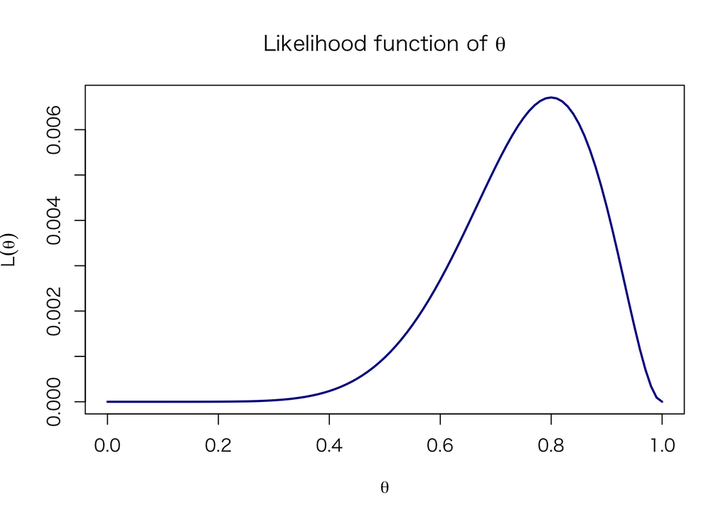

```r
lik_2 <- function(theta) {
    ## Argument: theta = probability of head
    ## Return: L = likelihood of theta given D
    L <- theta^8 * (1 - theta)^2
    return(L)
}
curve(lik_2, from = 0, to = 1, lwd = 2, col = "darkblue",
      xlab = expression(theta), ylab = expression(L(theta)),
      main = expression(paste("Likelihood function of ", theta)))
```

#### Log Likelihood

Let’s visualize the likelihood and log-likelihood functions.

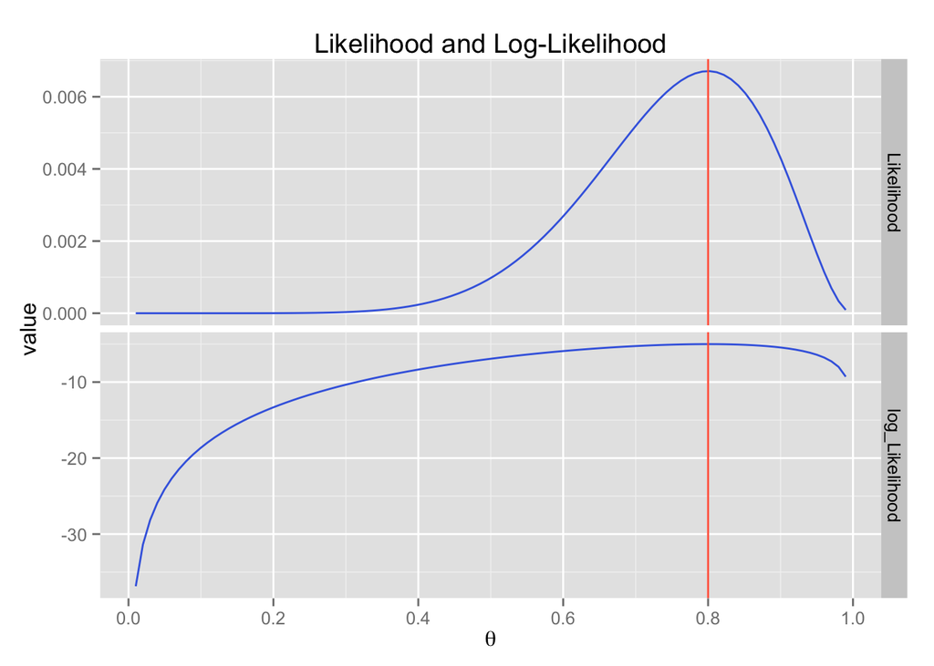

```r
v_theta <- seq(0.01, 0.99, length = 100)
L <- lik_2(v_theta)
lL <- log(L)
df <- data.frame(theta = v_theta,
                 Likelihood = L,
                 log_Likelihood = lL)
df <- melt(df, id = "theta")
p_lik_2 <- ggplot(df, aes(theta, value)) +
    geom_line(color = "royalblue") +
    scale_x_continuous(breaks = seq(0, 1, by = .2)) +
    facet_grid(variable ~ ., scales = "free_y") +
    geom_vline(xintercept = 0.8, color = "tomato") +
    labs(x = expression(theta), title = "Likelihood and Log-Likelihood")
print(p_lik_2)
```

Back to Class Materials